# Week 7: Affiliation Networks

Author

Ryan Light

## Introduction

How do social actors or entities connect to one another? On its face the answer is obvious: Actors are directly tied to one another through social relations (friends with, talks to, advice from, and so on). But, social scientists for some time have viewed social connectivity more broadly to include how actors connect to one another through indirect ties through co-membership or affiliation (members of the same team, members of the same corporate board, co-authorhip, and so on). As Cooley wrote, “A man may regarded as the point of intersection of an indefinite number of circles representing social groups, having as many arcs passing through him as there are groups.”

When we discussion affiliation networks, we ask:

What does it mean to be affiliated through a literal group, activity, or event?

And we may also ask:

What does it mean to be connected through a generic group or an abstraction?

It is probably not controversial to claim that people who are in the exact same social group share some type of meaningful connection through being members in the same group. If I attend a book club with you, then I am likely to share numerous characteristics, at minimum a shared appreciation of similar books. However, if we attend book clubs in different cities, does generic book club membership provide a meaningful tie?

Scholars interested in duality and affiliation are interested in these kinds of questions, but they extend to non-human entities as well, like scientific papers or emotions, that can be modeled as two-mode or affiliation networks.

Earlier work on duality (Breiger 1974) builds upon Cooley’s idea: People intersect through their associations, which defines (in part) their individuality. The concept of duality recognizes that relations among groups implies relations among individuals or vice versa.

As Breiger(1974:87) writes, “With respect to the membership network…persons who are actors in one picture (the P matrix) are with equal legitimacy viewed as connections in the dual picture (the G matrix), and conversely for groups.”

The resulting network after these transformations: - Is always symmetric - The diagonal tells you how many groups (persons) a person (group) belongs to (has).

We can see how these types of transformations work by turning to a toy example.

First, we should load the packages that we will need in this workshop. We will use `bibliometrix` for some two mode science network analysis, `igraph` for network analysis and visualization, `ggraph` for visualization, `udpipe` for some language parsing, and `dplyr`, `tidygraph`, and `ggforce` for a few data organization and visualization tasks. We use `tidytext` and `widyr` for some text processing functions.

```r
library(bibliometrix)
library(igraph)
library(ggraph)
library(udpipe)
library(dplyr)
library(tidygraph)
library(ggforce)
library(tidytext)
library(widyr)
```

## Affiliation Example

Let’s begin with a person-to-group matrix

Each column is a group, each cell is a person, and the cell=1 if the person in that row belongs to the group in that column. You can calculate how many groups shared between two individuals by comparing the rows. Identify every column where both rows equals 1 and sum them. This is the overlap.

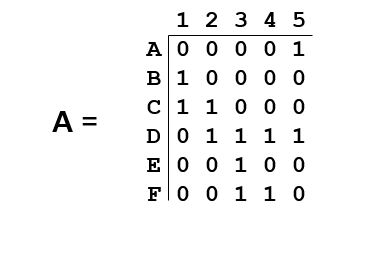

You can also tell the total number of group members by summing the columns and the total number of groups/indvidual by summing the rows.

Let’s make a matrix in **R**.

```r
one <- c(0, 1, 1, 0, 0, 0)
two <- c(0, 0, 1, 1, 0, 0)
three <- c(0, 0, 0, 1, 1, 1)
four <- c(0, 0, 0, 1, 0, 1)
five <- c(1, 0, 0, 1, 0, 0)

dual <- cbind(one, two, three, four, five)

rownames(dual) <- c("A", "B", "C", "D", "E", "F")

print(dual)
```

```
  one two three four five
A   0   0     0    0    1
B   1   0     0    0    0
C   1   1     0    0    0
D   0   1     1    1    1
E   0   0     1    0    0
F   0   0     1    1    0
```

## Duality & Matrix Algebra

Recall that the matrix is a simple and elegant way to manipulate networks. That is most obviously the case, perhaps, when thinking through duality.

From persons-to-groups to persons *and* groups.

If we multiple our Persons-to-Group matrix by its transpose, we have a Person matrix.

If we multiply the transpose of our Persons-to-Group matrix by the matrix itself, we have the Groups matrix.

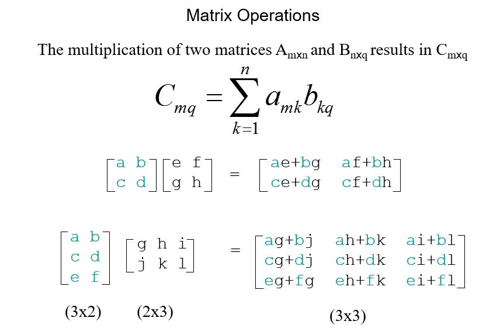

The Person-Person Matrix:

```r
person <- dual %*% t(dual)

print(person)
```

```
  A B C D E F
A 1 0 0 1 0 0
B 0 1 1 0 0 0
C 0 1 2 1 0 0
D 1 0 1 4 1 2
E 0 0 0 1 1 1
F 0 0 0 2 1 2
```

The Group-Group Matrix:

```r
groups <- t(dual) %*% dual

print(groups)
```

```
      one two three four five
one     2   1     0    0    0
two     1   2     1    1    1
three   0   1     3    2    1
four    0   1     2    2    1
five    0   1     1    1    2
```

## Bipartite Network

The general class of affiliation networks are known as *bipartite* or *two-mode* networks. The matrix transformation described above where we transform the network from two-mode to one-mode is called a *projection*.

One-mode projections, while perhaps more easy to understand, obviously involve a substantial loss of information.

While it remains more common, perhaps, to project two-mode networks, increasing work is looking at the tractability of keeping two-mode networks as two-modes.

## Science Networks

Science networks have been a major area where duality has been examined. We can think of all of the two-mode networks that structure science: People in labs, departments, etc or ideas in books, articles, etc. From bibliographic records we can construct numerous two-mode networks and project them to one-mode networks if we so choose. We can plot university by article or university by journal networks. We can plot country by keyword networks or typical coauthorship or cocitation networks.

So, we can also start by reading the data into `Bibliometrix`.

### Introduction to **Bibliometrix**

First, we need to bring the raw WoS data into a readable file. We can do this with the `convert2df` function in `Bibliometrix`. This requires a path for where the raw files are stored. We can grab those paths with the `list.files` function and be sure to specify that `full.names = TRUE` to grab the entire path.

```r
sh.articles <- list.files(path="data/articles/", full.names = TRUE)

sh.df <- convert2df(file=sh.articles, dbsource="isi", format="plaintext")
```

We will return to this data frame for reasons described below. But, it may be worthwhile to build a bibliometrix object and use some of this packages functions. We can use the `biblioAnalysis` function to build things and then use `summary` and `plot` to see an overview of the corpus.

```r
sh.biblio <- biblioAnalysis(sh.df, sep=";")

summary(sh.biblio, k=10)
```

```
MAIN INFORMATION ABOUT DATA

 Timespan                              1970 : 2023
 Sources (Journals, Books, etc)        751
 Documents                             1679
 Annual Growth Rate %                  7.45
 Document Average Age                  9.97
 Average citations per doc             45.54
 Average citations per year per doc    3.182
 References                            60012

DOCUMENT TYPES
 abstract of published item            1
 article                               1249
 article; book                         1
 article; book chapter                 70
 article; early access                 56
 article; proceedings paper            19
 article; retracted publication        1
 book                                  8
 book review                           11
 correction                            1
 editorial material                    8
 editorial material; book chapter      3
 meeting abstract                      2
 note                                  1
 proceedings paper                     176
 review                                69
 review; book chapter                  2
 review; early access                  1

DOCUMENT CONTENTS
 Keywords Plus (ID)                    2345
 Author's Keywords (DE)                3725

AUTHORS
 Authors                               3405
 Author Appearances                    4661
 Authors of single-authored docs       247

```

[output cut: 124 more lines]

```


Most Relevant Keywords

   Author Keywords (DE)      Articles Keywords-Plus (ID)     Articles
1    STRUCTURAL HOLES             205    STRUCTURAL HOLES         979
2    SOCIAL NETWORKS              155    PERFORMANCE              485
3    SOCIAL CAPITAL               138    INNOVATION               392
4    INNOVATION                   105    KNOWLEDGE                288
5    SOCIAL NETWORK ANALYSIS      103    SOCIAL NETWORKS          218
6    NETWORKS                      85    EMBEDDEDNESS             193
7    STRUCTURAL HOLE               63    ABSORPTIVE-CAPACITY      192
8    SOCIAL NETWORK                62    COLLABORATION            170
9    BROKERAGE                     53    NETWORKS                 170
10   CENTRALITY                    37    IMPACT                   159
```

[figure not shown]

[figure not shown]

[figure not shown]

[figure not shown]

[figure not shown]

```r
plot(x=sh.biblio, k=5, pause=FALSE)
```

`Bibliometrix` has number useful functions and you can see a good introduction [here](https://www.bibliometrix.org/vignettes/Introduction_to_bibliometrix.html). For example, we can plot the co-authorship network using the `biblioNetwork` function on the data frame and specifying `analysis="collaboration` and `network=authors`.

```r
coauth <- biblioNetwork(sh.df, analysis="collaboration", network="authors", short=TRUE)
```

And then we can plot using `networkPlot` here we also remove isolates and only label the top 10 nodes.

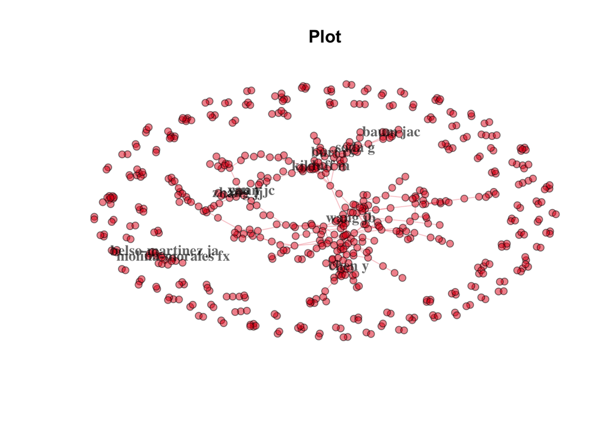

```r
networkPlot(coauth, remove.isolates=TRUE, label.n=10, cluster="none")
```

We can see that the network contains a small large component and numerous smaller components.

Manipulating the network in `Bibliometrix` isn’t always intuitive. So, we can move back and forth between the matrices and data frames conveniently generated by `Bibliometrix` and `igraph` or other packages.

### Co-authorship Network

Let’s use the author network as an example. First, let’s reduce the size of the corpus to just the look at 1990-2015 using `filter` in `dplyr`. Note that PY is the publication year.

```r
short <- sh.df %>% filter(PY>1989 & PY<2016)
```

```r
au.mat <- cocMatrix(short, Field="AU", sep=";")
```

Now we can use `graph_from_biadjacency_matrix()` to read the bipartite matrix into an **igraph** object.

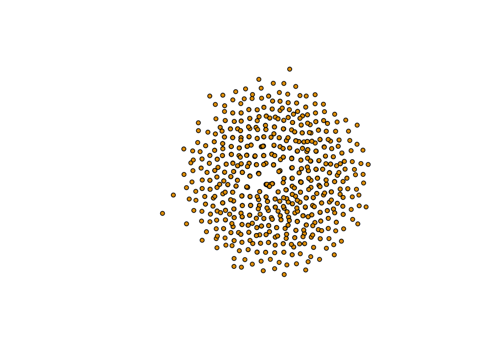

```r
au.g <- graph_from_biadjacency_matrix(au.mat)

au1mode.g <- bipartite_projection(au.g, multiplicity = TRUE, which=TRUE)

plot(au1mode.g, vertex.label=NA, vertex.size=4)
```

And we can grab the largest component using the `components` function in `igraph` and plot this component and `induced_subgraphs` to pull out the component.

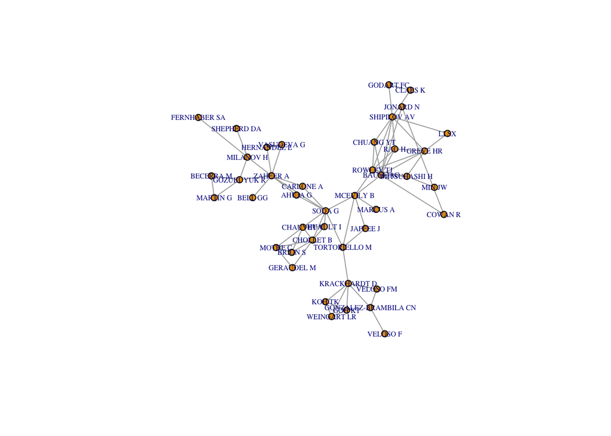

```r
comps <- components(au1mode.g)

bcomp <- which.max(comps$csize)

keep_ids <- V(au1mode.g)[comps$membership == bcomp]

aucomp.g <- induced_subgraph(graph=au1mode.g, vids=keep_ids)

plot.igraph(aucomp.g, layout=layout_with_kk, vertex.label.cex=.5, vertex.size=5)
```

### Keyword Networks

Keyword networks are another strategy for looking at the structure of a scientific field. The provide evidence of the epistemic space or the knowledge area in which scholars work.

Keyword networks are two-mode networks (articles x keywords) and we can keep them as two-modes or project them to a keyword x keyword network.

Let’s look at both of these networks in turn.

```r
kw.mat <- cocMatrix(sh.df, Field="DE")

kw.2mode <- graph_from_biadjacency_matrix(kw.mat)
```

We can plot the two-mode keyword network after removing any isolates or articles without any keywords using `delete_vertices` in `igraph`.

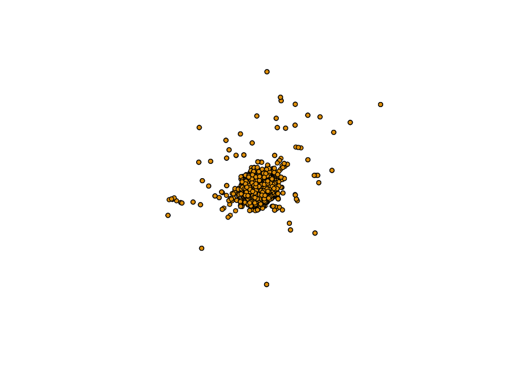

```r
kw2.noiso <- delete_vertices(kw.2mode, which(degree(kw.2mode)==0))

plot(kw2.noiso, layout=layout_with_fr, vertex.label=NA, vertex.size=4)
```

We can see that there appears to be a large connected component and many smaller components. This isn’t super informative, but we can graph some basic statistics for reference. Here, we count the number of components of various sizes, the degree centralization (`centr_degree()`), and the edge density.

```r
#can examine the components here

print(table(components(kw2.noiso)$csize))
```

```
   3    4    5    6    7    8    9   11   15 4724
   1    6   22   13    5    3    3    1    1    1
```

```r
#centralization

print(centr_degree(kw2.noiso)$centralization)
```

```
[1] 0.04006339
```

```r
# density

print(edge_density(kw2.noiso))
```

```
[1] 0.0005306664
```

Let’s dig deeper into the large component. First, we use `components` from `igraph` then we identify the largest component using `which.max` in base **R**.

```r
comps <- components(kw.2mode)

bigcomp <- which.max(comps$csize)
```

Next, we identify the vertices that are in the group identified with `which.max` using brackets and shrink the graph using `induced_subgraph` in `igraph`.

```r
vert_ids <- V(kw.2mode)[comps$membership == bigcomp]

kw2.gcc <- induced_subgraph(kw.2mode, vert_ids)
```

Let’s look at some clusters using `cluster_louvain` and `plot` in `igraph`.

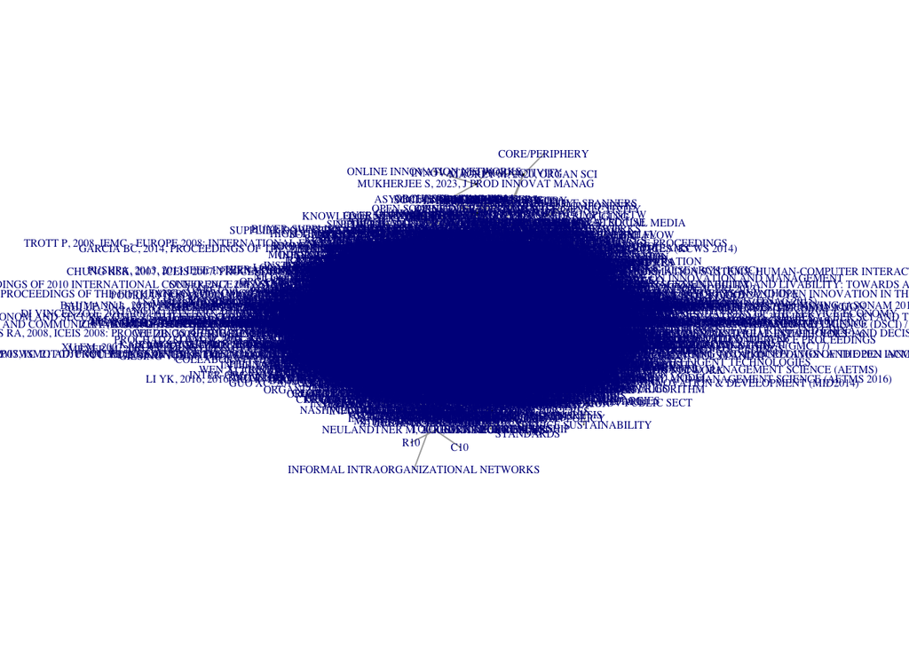

```r
lv <- cluster_louvain(kw2.gcc)

plot(kw2.gcc, layout=layout_with_kk, vertex.color=lv$membership, vertex.label.cex=.5, vertex.size=degree(kw2.gcc)/5)
```

The labels make it very difficult to read, so let’s see if we can plot only the one’s that are attached to nodes with high degree. We can combine `which` and `quantile` to do this task.

```r
lab.keep <- which(degree(kw2.gcc) > (quantile(degree(kw2.gcc), .99)
))
```

And then we plot using `ifelse` to label only those in the top group.

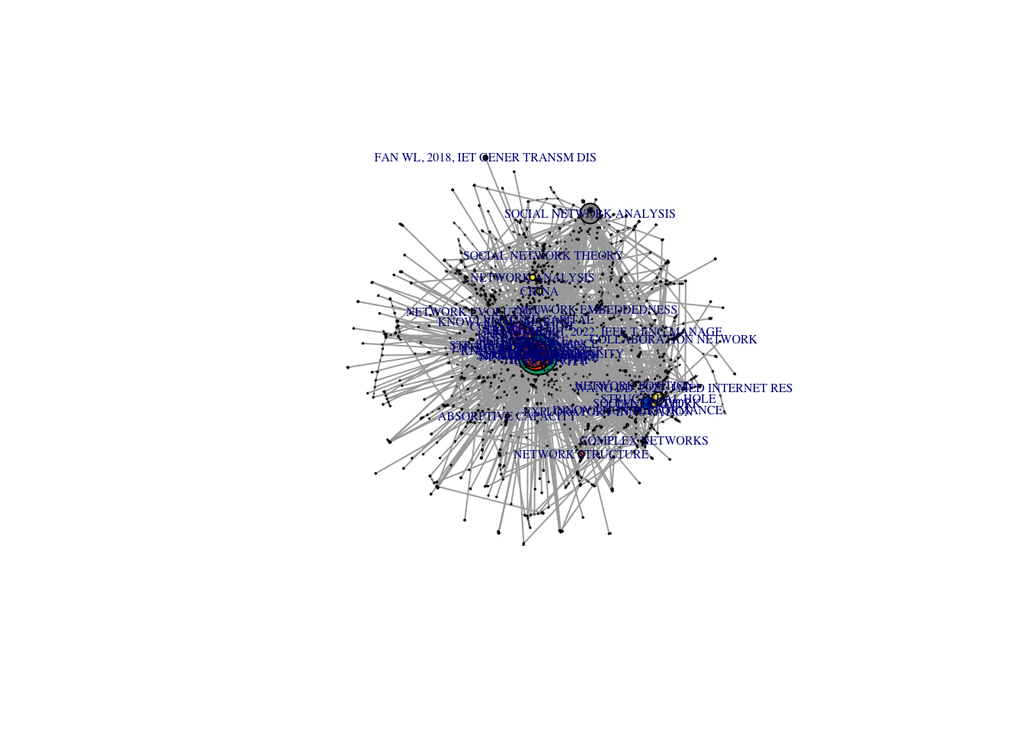

```r
plot(kw2.gcc, vertex.label = ifelse(V(kw2.gcc) %in% lab.keep, V(kw2.gcc)$name, NA),
     vertex.color=lv$membership, vertex.label.cex=.5,      vertex.size=degree(kw2.gcc)/10)
```

Still, somewhat of a mess, but we can imagine how pruning the network may lead to something that helps us to see the structure of this literature.

The one-mode approach is exactly the same, but we start by using `bipartite_projection` from **igraph** on the two-mode network and selecting `which="true"` because we know the keywords are in the columns of the original matrix. We can plot that network of course.

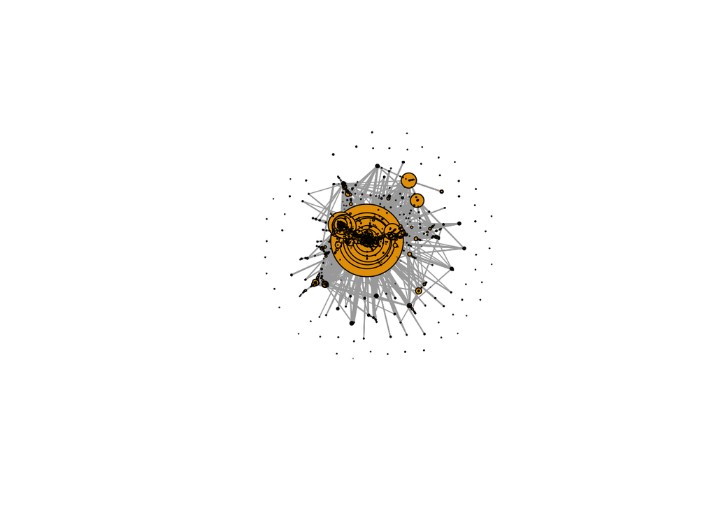

We can then go through the same kind of processes as the two mode networks in terms of finding the largest connected component, locating communities, plotting with reduced labels and so forth to locate patterns in the keyword structure.

### Text Networks

Text networks are increasingly common and relatively simple methods for document classification and/or generating thematic relationships across texts.

The goal is data reduction: Take a bunch of texts and simplify the relationship between them and/or their ideas.

Fundamentally, these are bipartite networks consisting of documents and words. We can think of any number of networks in similar ways, such as cocitation networks that consist of documents and citations.

Steps in processing texts:

```
1. Find a collection of texts
2. Force the collection into a .csv (etc.)
3. Preprocess the text data
    - Remove stop words and or select POS (e.g. nouns)
    - N-grams?
    - Word length
    - Common words
4. Build document by word matrix
    - "Bag of words:" Word order doesn't matter
    - Weighted elements?: Common weight is tfidf
5. Project to terms or documents
6. Plot
```

Let’s build a text network and a network of documents from the Web of Science on “structural holes.”

`Bibliometrix` has some text analysis capabilities, but we may want more flexibility in terms of what counts as text and so on. For example, we can organize and clean the data by deleting articles that don’t have an abstract and by combining keywords, titles, and abstracts.

Next, we can parse the combined text field and tag the words in the field by part-of-speech by using a pos-tagger. In this case, we use `udpipe` by first downloading an English language model using `udpipe_download_model(language = "english-lines")` then loading it into our **R** session with the local path using `udpipe_load_model(file=pathname)`. Last, we use `udpipe_annotate` on the text field to tag each word with a part of speech. Here, we also use `filter` in `dplyr` to select on nouns, but you may or may not want to look only at nouns.

```r
holes <- short %>% filter(AB != "")

holes$text <- paste(holes$DE, holes$TI, holes$AB)

m_eng_lines   <- udpipe_download_model(language = "english-lines")
m_eng_lines_path <- m_eng_lines$file_model
m_eng_lines_loaded <- udpipe_load_model(file=m_eng_lines_path)

text_annotated <- udpipe_annotate(m_eng_lines_loaded, x = holes$text) %>%
      as.data.frame() %>%
      select(-sentence)

nouns <- text_annotated %>% filter(upos=="NOUN")
```

After we select nouns, we can also clean the data in some ways that are typical for text networks, such as getting rid of short words, numbers, and words that appear only a handful of times, here 10 or fewer times. You see that most of these cleaning steps use either **base R** or `dplyr`.

```r
nouns$lemma <- tolower(nouns$lemma)

data("stop_words")

nouns <- nouns %>%
  filter(!lemma %in% stop_words$word)

word_count <-as.data.frame(table(nouns$lemma))

word_count <- rename(word_count, lemma = Var1)

word_count$isnum <- nchar(gsub("[^0-9]+", "", word_count$lemma))

word_count <- word_count %>% filter(isnum==0)

word_count$lemma <- as.character(word_count$lemma)

word_count$wlength <- nchar(word_count$lemma)

word_count <- word_count %>% filter(wlength>3)

word_count <- word_count %>% filter(Freq>10)

word_count$keep <- 1

noun_fin <- left_join(nouns, word_count)

noun_fin[is.na(noun_fin)] = 0

noun_fin <- noun_fin %>% filter(keep==1)
```

It is common to adjust the weight of tokens or words by their frequency so very frequent words are penalized. We can use `tidytext` for that.

```r
art_nouns <- noun_fin %>%
    count(doc_id, lemma, sort = TRUE)

total_nouns <- art_nouns %>%
  group_by(doc_id) %>%
  summarize(total = sum(n))

art_nouns <- left_join(art_nouns, total_nouns)

noun_tf_idf <- art_nouns %>% bind_tf_idf(lemma, doc_id, n)
```